# EC 502 HW3 R Notebook

Laya Dang (pd03@bu.edu)

# Data Import, Clean, and Set-up

### Import libraries

```r
suppressPackageStartupMessages({
  library(tidyverse)
  library(ggplot2)
})
```

### Load the dataset:

```r
country_data = read.csv("cross_country_data.csv")
head(country_data, 10)
```

|  | Country | Year | SavingsRate | RealGDP | LaborForce | HumanCapital | PhysicalCapital |
| --- | --- | --- | --- | --- | --- | --- | --- |
| 1 | Albania | 1980 | 0.3934749 | 9981.908 | 0.9249071 | 2.395581 | 42834.52 |
| 2 | Albania | 1981 | 0.4208891 | 10555.427 | 0.9514943 | 2.445612 | 45231.09 |
| 3 | Albania | 1982 | 0.4482948 | 10866.670 | 0.9771618 | 2.496687 | 47943.00 |
| 4 | Albania | 1983 | 0.4195175 | 10986.740 | 1.0006725 | 2.548830 | 50831.43 |
| 5 | Albania | 1984 | 0.3768510 | 10849.229 | 1.0246358 | 2.588237 | 53751.48 |
| 6 | Albania | 1985 | 0.3867719 | 11042.415 | 1.0539739 | 2.624506 | 56010.12 |
| 7 | Albania | 1986 | 0.3833166 | 11660.205 | 1.0901078 | 2.648263 | 58482.48 |
| 8 | Albania | 1987 | 0.3503911 | 11568.308 | 1.1281416 | 2.672236 | 61068.25 |
| 9 | Albania | 1988 | 0.3539001 | 11403.967 | 1.1635048 | 2.696425 | 63407.10 |
| 10 | Albania | 1989 | 0.3725055 | 12526.185 | 1.1956922 | 2.720833 | 66093.03 |

### Calculate (real) GDP per worker in 1981 and 2010:

```r
country_data <- country_data %>%
  transform(output_per_worker = RealGDP / LaborForce)

country_data_gdp_per_worker_1981_2010 <- country_data %>%
  filter(Year %in% c(1981, 2010)) %>%
  select(Country, Year, output_per_worker) %>%
  pivot_wider(names_from = Year,
             values_from = output_per_worker,
             names_prefix = "output_per_worker_")

head(country_data_gdp_per_worker_1981_2010, 5)
```

| Country | output_per_worker_1981 | output_per_worker_2010 |
| --- | --- | --- |
| Albania | 11093.53 | 24308.51 |
| Argentina | 24358.72 | 37174.97 |
| Australia | 52400.84 | 72687.02 |
| Austria | 49189.03 | 71225.79 |
| Bahrain | 74160.12 | 43394.25 |

### Average savings rate:

```r
summary_country_data <- country_data %>%
  group_by(Country) %>%
  summarise_at(vars(SavingsRate), list(savings_mean = mean))

head(summary_country_data, 10)
```

| Country | savings_mean |
| --- | --- |
| Albania | 0.27878799 |
| Argentina | 0.18497245 |
| Australia | 0.28747278 |
| Austria | 0.28031141 |
| Bahrain | 0.25863202 |
| Bangladesh | 0.16582476 |
| Barbados | 0.09136177 |
| Belgium | 0.26981514 |
| Belize | 0.14530192 |
| Benin | 0.10756875 |

### Average growth rate of the labor force and average growth rate of GDP per worker (from 1981 to 2010):

t = 1981

T = 2010 - 1981 = 29

formula: 1/29 * ln(val at 2010 / val at 1981)

(log in R has base e)

```r
# GET SAVINGS MEAN
summary_country_data <- country_data %>%
  group_by(Country) %>%
  summarise_at(vars(SavingsRate), list(savings_mean = mean))

# GET AVG GROWTH RATE OF LABOR (n) and AVG GROWTH RATE OF GDP PER WORKER (g)
summary_country_data <- country_data %>%
  filter(Year %in% c(1981, 2010)) %>%
  select(Country, Year, LaborForce, output_per_worker) %>%
  pivot_wider(names_from = Year,
              values_from = c(output_per_worker, LaborForce),
              names_sep = "_",
              names_prefix = "year_") %>%
  transform(avg_growth_labor = (1/29) * log(LaborForce_year_2010 / LaborForce_year_1981)) %>%
  transform(avg_growth_gdp_per_worker = (1/29) * log(output_per_worker_year_2010 / output_per_worker_year_1981)) %>%
  left_join(summary_country_data, by = "Country")

head(summary_country_data %>% select(Country, avg_growth_labor, avg_growth_gdp_per_worker, savings_mean), 5)
```

|  | Country | avg_growth_labor | avg_growth_gdp_per_worker | savings_mean |
| --- | --- | --- | --- | --- |
| 1 | Albania | -0.001273320 | 0.02705051 | 0.2787880 |
| 2 | Argentina | 0.012385833 | 0.01457744 | 0.1849724 |
| 3 | Australia | 0.020416269 | 0.01128414 | 0.2874728 |
| 4 | Austria | 0.009319133 | 0.01276498 | 0.2803114 |
| 5 | Bahrain | 0.055696186 | -0.01847930 | 0.2586320 |

# Question (1) Descriptive Statistics

### a) number of countries

```r
country_data %>%  summarise(num_countries = n_distinct(Country))
```

| num_countries |
| --- |
| 118 |

### b) mean (across countries) of output per worker 1981, output per worker 2010, savings rate, growth of labor force, growth rate of GDP per worker

```r
summary_country_data %>%
  summarise_at(vars(output_per_worker_year_1981,
                    output_per_worker_year_2010,
                    savings_mean,
                    avg_growth_labor,
                    avg_growth_gdp_per_worker),
               list(mean = mean)) %>%
  mutate(across(everything(), ~ round(., digits = 4))) %>%
  pivot_longer(cols=everything(), names_to = "variable", values_to = "value")
```

| variable | value |
| --- | --- |
| output_per_worker_year_1981_mean | 27042.8747 |
| output_per_worker_year_2010_mean | 34551.1683 |
| savings_mean_mean | 0.2003 |
| avg_growth_labor_mean | 0.0225 |
| avg_growth_gdp_per_worker_mean | 0.0113 |

### c) standard deviation (of values above)

```r
summary_country_data %>%
  summarise_at(vars(output_per_worker_year_1981,
                    output_per_worker_year_2010,
                    savings_mean,
                    avg_growth_labor,
                    avg_growth_gdp_per_worker), list(sd = sd)) %>%
  mutate(across(everything(), ~ round(., digits = 4))) %>%
  pivot_longer(cols=everything(), names_to = "variable", values_to = "value")
```

| variable | value |
| --- | --- |
| output_per_worker_year_1981_sd | 37952.7301 |
| output_per_worker_year_2010_sd | 33102.0465 |
| savings_mean_sd | 0.0688 |
| avg_growth_labor_sd | 0.0131 |
| avg_growth_gdp_per_worker_sd | 0.0181 |

### d) min and max of vals above

Min:

```r
summary_country_data %>%
  summarise_at(vars(output_per_worker_year_1981,
                    output_per_worker_year_2010,
                    savings_mean,
                    avg_growth_labor,
                    avg_growth_gdp_per_worker),
               list(min = min)) %>%
  mutate(across(everything(), ~ round(., digits = 4))) %>%
  pivot_longer(cols=everything(), names_to = "variable", values_to = "value")
```

| variable | value |
| --- | --- |
| output_per_worker_year_1981_min | 886.8293 |
| output_per_worker_year_2010_min | 967.6390 |
| savings_mean_min | 0.0479 |
| avg_growth_labor_min | -0.0141 |
| avg_growth_gdp_per_worker_min | -0.0347 |

Max:

```r
summary_country_data %>%
  summarise_at(vars(output_per_worker_year_1981,
                    output_per_worker_year_2010,
                    savings_mean,
                    avg_growth_labor,
                    avg_growth_gdp_per_worker),
               list(max = max)) %>%
  mutate(across(everything(), ~ round(., digits = 4))) %>%
  pivot_longer(cols=everything(), names_to = "variable", values_to = "value")
```

| variable | value |
| --- | --- |
| output_per_worker_year_1981_max | 241085.8648 |
| output_per_worker_year_2010_max | 155184.3351 |
| savings_mean_max | 0.4455 |
| avg_growth_labor_max | 0.0830 |
| avg_growth_gdp_per_worker_max | 0.0820 |

# Question (2) Unconditional Convergence

Plot:

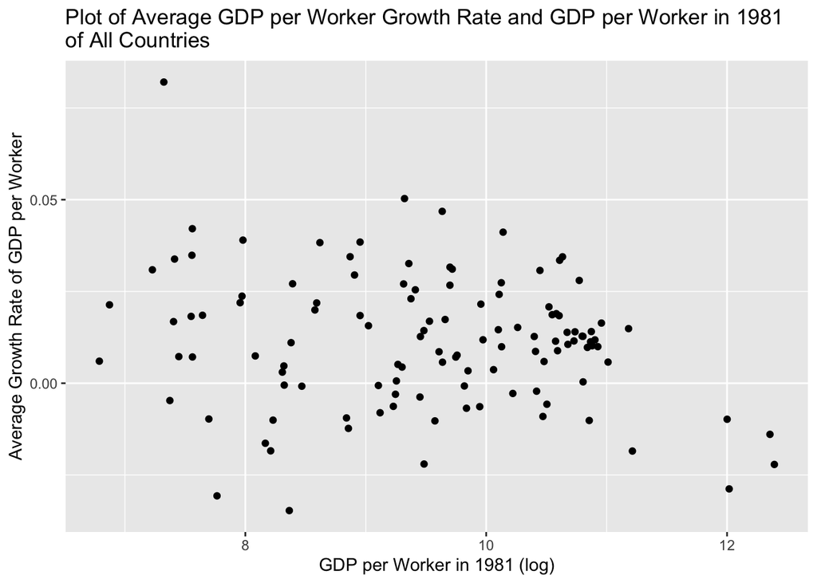

```r
summary_country_data %>%
  ggplot(aes(x=log(output_per_worker_year_1981), y=avg_growth_gdp_per_worker)) +
  geom_point() +
  labs(title="Plot of Average GDP per Worker Growth Rate and GDP per Worker in 1981\nof All Countries ",
        x ="GDP per Worker in 1981 (log)", y = "Average Growth Rate of GDP per Worker")
```

OLS Regression:

```r
ols_data <- data.frame(
  # y value:
  avg_growth_gdp_per_worker = summary_country_data[['avg_growth_gdp_per_worker']],
  # x value:
  log_output_per_worker_year_1981 = log(summary_country_data[['output_per_worker_year_1981']])
)
head(ols_data, 3)
```

|  | avg_growth_gdp_per_worker | log_output_per_worker_year_1981 |
| --- | --- | --- |
| 1 | 0.02705051 | 9.314117 |
| 2 | 0.01457744 | 10.100645 |
| 3 | 0.01128414 | 10.866678 |

```r
ols_model <- lm(avg_growth_gdp_per_worker~log_output_per_worker_year_1981, data=ols_data)
summary(ols_model)
```

```
##
## Call:
## lm(formula = avg_growth_gdp_per_worker ~ log_output_per_worker_year_1981,
##     data = ols_data)
##
## Residuals:
##      Min       1Q   Median       3Q      Max
## -0.04915 -0.01204  0.00226  0.01044  0.06475
##
## Coefficients:
##                                  Estimate Std. Error t value Pr(>|t|)
## (Intercept)                      0.037238   0.012788   2.912  0.00431 **
## log_output_per_worker_year_1981 -0.002724   0.001332  -2.045  0.04312 *
## ---
## Signif. codes:  0 '***' 0.001 '**' 0.01 '*' 0.05 '.' 0.1 ' ' 1
##
## Residual standard error: 0.0179 on 116 degrees of freedom
## Multiple R-squared:  0.0348, Adjusted R-squared:  0.02648
## F-statistic: 4.182 on 1 and 116 DF,  p-value: 0.04312
```

From the above OLS model, we get the formula where g = 0.037238 + -0.002724 * log(Y/L) + 0.0179

The estimate for b1(hat) is -0.002724 and its standard error is 0.001332

# Question (3) MRW Revisited

```r
ols_data_mrw <- data.frame(
  # y value:
  avg_growth_gdp_per_worker = summary_country_data[['avg_growth_gdp_per_worker']],
  # x1 value:
  log_output_per_worker_year_1981 = log(summary_country_data[['output_per_worker_year_1981']]),
  # x2 value:
  log_avg_growth_labor_plus_0.05 = log(summary_country_data[['avg_growth_labor']] + 0.05 )
)

head(ols_data_mrw, 5)
```

|  | avg_growth_gdp_per_worker | log_output_per_worker_year_1981 | log_avg_growth_labor_plus_0.05 |
| --- | --- | --- | --- |
| 1 | 0.02705051 | 9.314117 | -3.021529 |
| 2 | 0.01457744 | 10.100645 | -2.774417 |
| 3 | 0.01128414 | 10.866678 | -2.653331 |
| 4 | 0.01276498 | 10.803426 | -2.824823 |
| 5 | -0.01847930 | 11.213982 | -2.247186 |

```r
ols_model_mrw <- lm(avg_growth_gdp_per_worker~log_output_per_worker_year_1981+log_avg_growth_labor_plus_0.05, data=ols_data_mrw)
summary(ols_model_mrw)
```

```
##
## Call:
## lm(formula = avg_growth_gdp_per_worker ~ log_output_per_worker_year_1981 +
##     log_avg_growth_labor_plus_0.05, data = ols_data_mrw)
##
## Residuals:
##       Min        1Q    Median        3Q       Max
## -0.047635 -0.009087 -0.001348  0.008121  0.059462
##
## Coefficients:
##                                  Estimate Std. Error t value Pr(>|t|)
## (Intercept)                     -0.062898   0.022800  -2.759  0.00675 **
## log_output_per_worker_year_1981 -0.003519   0.001218  -2.889  0.00462 **
## log_avg_growth_labor_plus_0.05  -0.040776   0.007993  -5.101 1.34e-06 ***
## ---
## Signif. codes:  0 '***' 0.001 '**' 0.01 '*' 0.05 '.' 0.1 ' ' 1
##
## Residual standard error: 0.01623 on 115 degrees of freedom
## Multiple R-squared:  0.2129, Adjusted R-squared:  0.1992
## F-statistic: 15.55 on 2 and 115 DF,  p-value: 1.051e-06
```

The value of alpha is implied to be 0.003519, which means labor share is around (1 - 0.003519) 0.996481, or the majority of output. This is not consistent with the standard assumption of 2/3.

The R-squared is 0.2129, which indicates that the model does not do a good job of indicating the variance in the model, and there is not much predictive power the coefficients have. The model only explains 21.29% of the variance.

# Question (4) HJ Levels Accounting

A = (Y/L) * (K/Y)^(1-a/a) * (L/H)

Calculate parts of the equation:

```r
hj_data <- country_data %>%
  filter(Year == 2010) %>%
  transform(capital_per_output = PhysicalCapital / RealGDP) %>%  # capital per output in 2010
  transform(recip_human_cap = 1 / HumanCapital) %>%  # reciprocal of human capital per person
  select(Country, Year, capital_per_output, recip_human_cap, HumanCapital)

head(hj_data %>% select(-HumanCapital), 5)
```

|  | Country | Year | capital_per_output | recip_human_cap |
| --- | --- | --- | --- | --- |
| 1 | Albania | 2010 | 4.034723 | 0.3328644 |
| 2 | Argentina | 2010 | 3.398882 | 0.3547817 |
| 3 | Australia | 2010 | 3.613600 | 0.2951154 |
| 4 | Austria | 2010 | 3.385438 | 0.3521654 |
| 5 | Bahrain | 2010 | 3.982973 | 0.3500738 |

Estimate A:

```r
hj_data <- hj_data %>%
  left_join(summary_country_data %>% select(Country, output_per_worker_year_2010), by="Country") %>%
  transform(A_estimate = output_per_worker_year_2010 * capital_per_output^(2/9) * recip_human_cap) %>%
  transform(log_A_estimate = log(A_estimate))

head(hj_data %>%  select(A_estimate, log_A_estimate), 5)
```

|  | A_estimate | log_A_estimate |
| --- | --- | --- |
| 1 | 11031.92 | 9.308548 |
| 2 | 17309.58 | 9.759015 |
| 3 | 28538.78 | 10.259019 |
| 4 | 32890.93 | 10.400952 |
| 5 | 20652.43 | 9.935588 |

Summary statistics:

```r
hj_data %>%
  summarise_at(vars(log_A_estimate), list(log_A_mean = mean, log_A_sd = sd))
```

| log_A_mean | log_A_sd |
| --- | --- |
| 9.155138 | 1.105463 |

Plots:

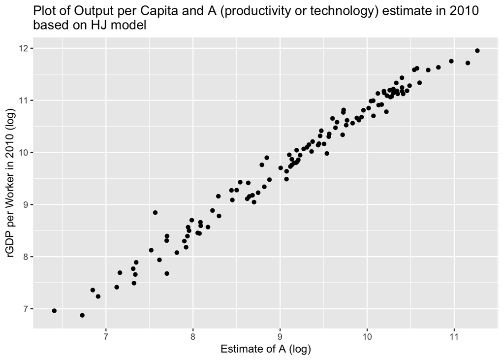

```r
hj_data %>%
  ggplot(aes(x=log_A_estimate, y=log(output_per_worker_year_2010))) +
  geom_point() +
  labs(title="Plot of Output per Capita and A (productivity or technology) estimate in 2010 \nbased on HJ model",
        x ="Estimate of A (log)", y = "rGDP per Worker in 2010 (log)")
```

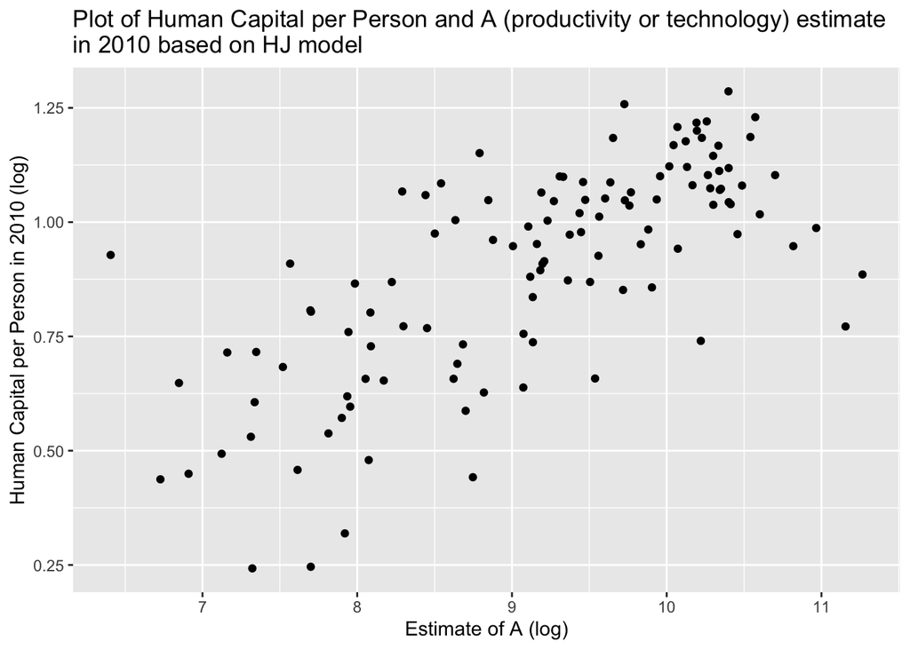

```r
hj_data %>%
  ggplot(aes(x=log_A_estimate, y=log(HumanCapital))) +
  geom_point() +
  labs(title="Plot of Human Capital per Person and A (productivity or technology) estimate \nin 2010 based on HJ model",
        x ="Estimate of A (log)", y = "Human Capital per Person in 2010 (log)")
```

```r
hj_ols_model <- lm(log(output_per_worker_year_2010)~log_A_estimate, data=hj_data)
summary(hj_ols_model)
```

```
##
## Call:
## lm(formula = log(output_per_worker_year_2010) ~ log_A_estimate,
##     data = hj_data)
##
## Residuals:
##      Min       1Q   Median       3Q      Max
## -0.53717 -0.11691 -0.00643  0.11088  0.78249
##
## Coefficients:
##                Estimate Std. Error t value Pr(>|t|)
## (Intercept)    -0.44376    0.13704  -3.238  0.00157 **
## log_A_estimate  1.12432    0.01486  75.654  < 2e-16 ***
## ---
## Signif. codes:  0 '***' 0.001 '**' 0.01 '*' 0.05 '.' 0.1 ' ' 1
##
## Residual standard error: 0.1777 on 116 degrees of freedom
## Multiple R-squared:  0.9801, Adjusted R-squared:   0.98
## F-statistic:  5724 on 1 and 116 DF,  p-value: < 2.2e-16
```

The estimated b1(hat), or the coefficient for A, is 1.12432, and since this is a positive coefficient, the model suggests that living standards (Y/L) is higher in nations with higher productivity (A). The R-squared is 0.9801, which means the model is a good fit and explains 98.01% of the variance in the data.